# Check-In Meeting

Thursday, January 21, 2016

## Today's Agenda

1. Introductions …who are we?
2. Goal Setting …what do we want to achieve?
3. Progress Update …what data do we have? what do we want?
4. Methods Discussion …how do can we best use all this information?
5. Next Steps …what's next?

## Introductions

## GOAL SETTING

- **The baseline conditions report should:**
  - provide a clear, data-driven overview of Yesler Terrace and the other Central Area Crescent neighborhoods
  - offer comparisons between the neighborhoods and Seattle as a whole across a wide range of topics
  - simplify the interpretation of data through the use of maps, graphs and summary statistics
  - make the results easily shareable and accessible to all partners

## PROGRESS UPDATE: Draft Report Outline

- **Introduction**
- **Community Characteristics**
- **Housing**
- **Transportation**
- **Environment**
- **Health & Wellbeing**
- **Economic Prosperity**
- **Education**
- **Real Estate & Development**
- **Urban Design & Placemaking**
- **Community & Culture**

[figure not shown]

## PROGRESS UPDATE: Data We Have

- **Introduction**
  - Area context (waterbodies, highways, urban vs rural land)
  - Urban Centers/Villages
  - Seattle neighborhood boundaries (City Clerk's unofficial boundaries)

## PROGRESS UPDATE: Data We Have (cont.)

- **Community Characteristics**
  - Household Density
  - Race & Ethnicity (Diversity Index, %PoC)
  - Nativity
  - English Proficiency
  - Age (Median Age, % children,  
    % elders)
  - Educational Attainment
  - Median Household Income
  - % Low Income (below 200% Poverty)

## PROGRESS UPDATE: Data We Have (cont.)

- **Housing**
  - Tenure (Rent vs. Own)
  - Types (SF vs. MF)
  - Age of Buildings
  - Cost-Burdening (Renter vs. Owners)
  - Median Gross Rent as % of HH Income
  - Median Gross Rent (Studio, 2BR, 3+BR)

## PROGRESS UPDATE: Data We Have (cont.)

- **Transportation**
  - Street network
  - Transit network (% HH > 500ft from transit node)
  - Transit frequency (% HH > 500ft from high freq. transit node)
  - Pedestrian network (% streets with sidewalks)
  - Bicycle network

## PROGRESS UPDATE: Data We Have (cont.)

- **Environment**
  - Tree canopy
  - Proximity to freeways (acceptable range?)
- **Health & Wellbeing**
  - Public health facilities (% HH within walking distance)
  - Proximity to parks and recreation facilities
  - Pea patches + fruit trees
  - Farmers' markets
- **Economic Prosperity**
  - Unemployment rate (by race?)

## PROGRESS UPDATE: Data We Have (cont.)

- **Education**
  - Schools
  - School Performance (WA Schools Report Card - Adequate Yearly Progress)
  - Proximity to computer/media centers
- **Real Estate & Development**
  - Building height limits
  - Land/Improvement Value (tax assessor)
  - Building permit density
  - Code violations density

## PROGRESS UPDATE: Data We Have (cont.)

- **Urban Design & Placemaking**
  - Historic Districts
  - Pedestrian Zones
  - Public spaces
  - View points
  - Public art installations
- **Community & Culture**
  - Public events (civic, arts, community)

## PROGRESS UPDATE: Data We Want

- **Housing**
  - Median home value
- **Environment**
  - Air quality (requires better understanding)
  - Hydrology/Green Infrastructure
  - Noise pollution, light pollution
- **Health & Wellbeing**
  - Overweight/obesity prevalence (children, adults)
  - Asthma prevalence
  - Food stamp-accepting businesses

## PROGRESS UPDATE: Data We Want

- **Economic Prosperity**
  - Major employers
  - % businesses owner by women or minorities
- **Education**
  - Other measures of success (besides AYP)
- **Real Estate & Development**
  - Property value estimates (Dupre + Scott?)
  - Development Capacity (source: Seattle OPCD)
  - Upcoming developments

## PROGRESS UPDATE: Data We Want

- **Urban Design & Placemaking**
  - Neighborhood character (photos)
  - Upcoming/propsed developments (photos)
- **Community & Culture**
  - Ethnic businesses
  - Cultural spaces & landmarks (religious, civic, etc.)

## METHODS DISCUSSION: Boundaries

[interactive chart not shown]

## METHODS DISCUSSION: Boundaries

[interactive chart not shown]

## METHODS DISCUSSION: Boundaries

[interactive chart not shown]

## METHODS DISCUSSION: Boundaries

[interactive chart not shown]

## METHODS DISCUSSION: Boundaries

[interactive chart not shown]

## METHODS DISCUSSION: Boundaries

[interactive chart not shown]

## METHODS DISCUSSION: Boundaries

[interactive chart not shown]

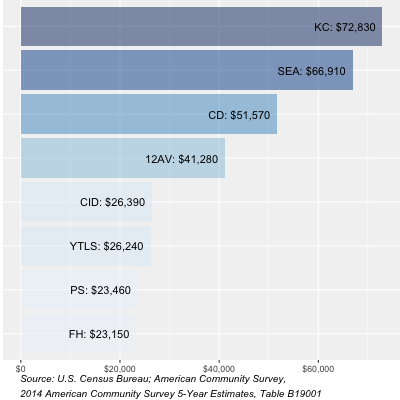

## METHODS DISCUSSION: Boundaries

[interactive chart not shown]

[figure not shown]

## QUESTIONS

- Do any of these boundaries need revision?
- Which option would be more useful:
  - Use Urban Village boundaries whenever possible?
  - Use only Census boundaries
- What is our data list missing?
- Who should be reach out to with specific data requests?

## NEXT STEPS

- Make revisions based on today's feedback
- Collect more data (niche data sets)
- Generate maps and graphs
- Produce draft report (PDF, webpage)
- Share draft with partners